# Model reproduction checklist

Breck Baldwin

3/18/2021

# Model overview

This document exists in the repository at https://github.com/codatmo/Simple_SIR as `index.Rmd` and rendered in html as https://codatmo.github.io/Simple_SIR/index.html.

### Validation checklist items completed

- Model description: Research goals, references, supplementary description as necessary.
- Data description and explicit data munging description.
- Small data set to validate model execution
- Divergent transitions report
- Rhat check
- Compare marginal posterior densities across chains
- Posterior predictive check
- Prior predictive check
- Simulated data parameter recovery

### Validation steps planned

- SBC (Simulation Based Calibration)

## Model description

Based on case study at https://mc-stan.org/users/documentation/case-studies/boarding_school_case_study.html. The case study is a detailed introduction to SIR models (Susceptible, Infectious, Resolved) and Bayesian modeling with Stan.

## Data

The data are freely available in the R package outbreaks, maintained as part of the [R Epidemics Consortium](http://www.repidemicsconsortium.org).

```r
library(cmdstanr)
library(outbreaks)
library(tidyverse)
library(stringr)
print_file <- function(file) {
  cat(paste(readLines(file), "\n", sep=""), sep="")
}

head(influenza_england_1978_school)
```

```
        date in_bed convalescent
1 1978-01-22      3            0
2 1978-01-23      8            0
3 1978-01-24     26            0
4 1978-01-25     76            0
5 1978-01-26    225            9
6 1978-01-27    298           17
```

Data tracks on a per day basis the number of boarding schools students `in_bed` which are considered Infected and `convalescent` which are considered Resolved in the SIR model, total N = 763. The mapping to data is The initial state is I = 1, S = 762, R=0.

### Data munging

The conversion to Stan input given the above data is as follows:

```r
# time series of cases
cases <- influenza_england_1978_school$in_bed  # Number of students in bed

# total count
N <- 763;

# times
n_days <- length(cases)
ts <- seq(1, n_days, by = 1)
t0 = 0

#initial conditions
i0 <- 1 # Infected
s0 <- N - i0 # Susceptible
r0 <- 0 # Resolved
y0 = c(S = s0, I = i0, R = r0)

compute_likelihood = 1

# data for Stan
data_sir <- list(n_days = n_days, i0 = i0, y0 = y0, s0 = s0, r0 = r0, t0 = t0, ts = ts,
                 N = N, cases = cases, compute_likelihood = compute_likelihood)
```

## Stan program

The Stan model is located at `Simple_SIR/stan/sir_negbin.stan`:

```
functions {
  real[] sir(real t, real[] y, real[] theta,
             real[] x_r, int[] x_i) {

      real S = y[1];
      real I = y[2];
      real R = y[3];
      real N = x_i[1];

      real beta = theta[1];
      real gamma = theta[2];

      real dS_dt = -beta * I * S / N;
      real dI_dt =  beta * I * S / N - gamma * I;
      real dR_dt =  gamma * I;

      return {dS_dt, dI_dt, dR_dt};
  }
}
data {
  int<lower=1> n_days;
  real y0[3];
  real t0;
  real ts[n_days];
  int N;
  int cases[n_days];
  int compute_likelihood;
}
transformed data {
  real x_r[0]; //need for ODE function
  int x_i[1] = { N }; //need for ODE function
}
parameters {
  real<lower=0> gamma;
  real<lower=0> beta;
  real<lower=0> phi_inv;
}
transformed parameters{
  real y[n_days, 3];
  real phi = 1. / phi_inv;
```

[output cut: 11 more lines]

```
  gamma ~ normal(0.4, 0.5);
  phi_inv ~ exponential(5);

  //sampling distribution
  //col(matrix x, int n) - The n-th column of matrix x. Here the number of infected people
  if (compute_likelihood == 1) {
    cases ~ neg_binomial_2(col(to_matrix(y), 2), phi);
  }
}
generated quantities {
  real R0 = beta / gamma;
  real recovery_time = 1 / gamma;
  real pred_cases[n_days];
  pred_cases = neg_binomial_2_rng(col(to_matrix(y), 2), phi);
}
```

## Running model

```r
model <- cmdstan_model(file.path("stan","sir_negbin.stan"))
fit_sir_negbin <- model$sample(
                data = data_sir)
```

[output not shown]

[output cut: 16 more lines]

```
Chain 3 Iteration:  800 / 2000 [ 40%]  (Warmup)
Chain 3 Iteration:  900 / 2000 [ 45%]  (Warmup)
Chain 3 Iteration: 1000 / 2000 [ 50%]  (Warmup)
Chain 3 Iteration: 1001 / 2000 [ 50%]  (Sampling)
Chain 3 Iteration: 1100 / 2000 [ 55%]  (Sampling)
Chain 3 Iteration: 1200 / 2000 [ 60%]  (Sampling)
Chain 3 Iteration: 1300 / 2000 [ 65%]  (Sampling)
Chain 3 Iteration: 1400 / 2000 [ 70%]  (Sampling)
Chain 3 Iteration: 1500 / 2000 [ 75%]  (Sampling)
Chain 3 Iteration: 1600 / 2000 [ 80%]  (Sampling)
Chain 3 Iteration: 1700 / 2000 [ 85%]  (Sampling)
Chain 3 Iteration: 1800 / 2000 [ 90%]  (Sampling)
Chain 3 Iteration: 1900 / 2000 [ 95%]  (Sampling)
Chain 3 Iteration: 2000 / 2000 [100%]  (Sampling)
Chain 3 finished in 10.5 seconds.
```

[output not shown]

```r
fit_sir_negbin$cmdstan_summary()
```

```
Inference for Stan model: sir_negbin_model
3 chains: each with iter=(1000,1000,1000); warmup=(0,0,0); thin=(1,1,1); 3000 iterations saved.

Warmup took (12, 4.2, 6.0) seconds, 22 seconds total
Sampling took (2.5, 10, 4.5) seconds, 17 seconds total

                 Mean     MCSE   StdDev     5%   50%   95%    N_Eff  N_Eff/s    R_hat

lp__              -65  5.5e-02      1.4    -68   -65   -64      659       38      1.0
accept_stat__    0.92  2.0e-03  1.0e-01   0.73  0.96   1.0  2.7e+03  1.6e+02  1.0e+00
stepsize__       0.60  5.1e-03  6.3e-03   0.60  0.60  0.61  1.5e+00  8.7e-02  3.3e+12
treedepth__       2.4  1.1e-02  5.7e-01    2.0   2.0   3.0  2.8e+03  1.6e+02  1.0e+00
n_leapfrog__      5.4  3.9e-02  2.0e+00    3.0   7.0   7.0  2.7e+03  1.6e+02  1.0e+00
divergent__      0.00      nan  0.0e+00   0.00  0.00  0.00      nan      nan      nan
energy__           67  6.9e-02  1.9e+00     65    67    71  7.3e+02  4.3e+01  1.0e+00

gamma            0.54  1.1e-03    0.045   0.47  0.54  0.62     1670       97      1.0
beta              1.7  2.1e-03    0.056    1.7   1.7   1.8      726       42      1.0
phi_inv          0.14  2.5e-03    0.080  0.050  0.12  0.28     1040       60     1.00
y[1,1]            759  9.9e-03     0.24    758   759   759      580       34      1.0
y[1,2]            3.3  9.3e-03     0.24    3.0   3.3   3.7      642       37      1.0
y[1,3]            1.0  1.7e-03    0.070   0.93   1.0   1.2     1680       98      1.0
y[2,1]            748  7.9e-02      1.8    745   748   750      538       31      1.0
y[2,2]             11  6.7e-02      1.6    8.8    11    13      572       33      1.0
y[2,3]            4.4  1.3e-02     0.37    3.9   4.4   5.0      771       45      1.0
y[3,1]            714  4.0e-01      9.2    701   715   725      517       30      1.0
y[3,2]             34  3.2e-01      7.4     25    33    45      534       31      1.0
y[3,3]             15  8.4e-02      2.0     13    15    18      552       32      1.0
y[4,1]            625  1.2e+00       29    580   629   660      562       33      1.0
y[4,2]             91  9.0e-01       22     65    88   125      594       35      1.0
y[4,3]             47  3.4e-01      7.9     37    46    59      542       32      1.0
y[5,1]            461  1.9e+00       51    377   465   532      730       42      1.0
y[5,2]            182  1.1e+00       33    135   180   237      859       50      1.0
y[5,3]            120  7.8e-01       20     93   117   151      630       37      1.0
y[6,1]            283  1.7e+00       52    200   284   363      977       57      1.0
y[6,2]            243  6.5e-01       26    200   243   285     1622       94      1.0
y[6,3]            237  1.1e+00       30    193   235   286      767       45      1.0
y[7,1]            165  1.1e+00       38    107   163   227     1282       75      1.0
y[7,2]            231  4.0e-01       17    202   231   258     1855      108      1.0
y[7,3]            367  1.1e+00       32    318   366   419      900       52      1.0
```

[output cut: 28 more lines]

```
pred_cases[5]     184  1.7e+00       81     79   173   324     2309      134     1.00
pred_cases[6]     244  1.8e+00       93    113   233   408     2791      162      1.0
pred_cases[7]     229  1.6e+00       87    106   220   386     2956      172     1.00
pred_cases[8]     181  1.3e+00       70     81   174   301     2922      170     1.00
pred_cases[9]     126  9.1e-01       49     55   121   212     2889      168     1.00
pred_cases[10]     87  7.6e-01       35     38    84   150     2166      126      1.0
pred_cases[11]     57  4.8e-01       24     24    54   101     2564      149     1.00
pred_cases[12]     37  3.0e-01       16     14    35    64     2724      158      1.0
pred_cases[13]     24  2.1e-01       11    9.0    22    43     2418      141      1.0
pred_cases[14]     15  1.5e-01      7.8    5.0    14    29     2653      154     1.00

Samples were drawn using hmc with nuts.
For each parameter, N_Eff is a crude measure of effective sample size,
and R_hat is the potential scale reduction factor on split chains (at
convergence, R_hat=1).
```

## Model validation

Below are the diagnostics used to help validate the model.

### Rhat check

Rhat values are below 1.1, see below:

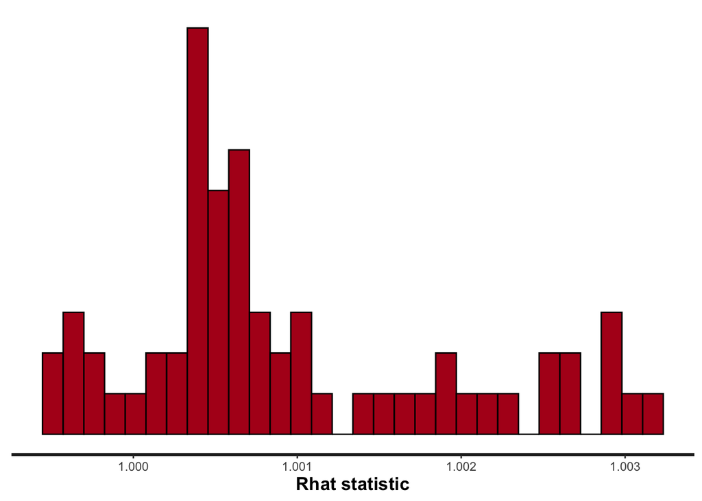

```r
library(rstan)
r_stan_sir_negbin <- rstan::read_stan_csv(fit_sir_negbin$output_files())
stan_rhat(r_stan_sir_negbin)
```

### Divergent transition check

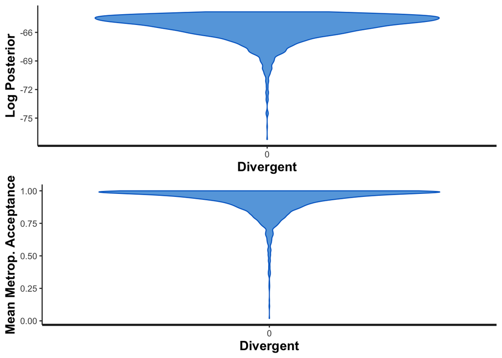

```r
stan_diag(r_stan_sir_negbin,information="divergence")
```

### Compare marginal posterier densities across chains

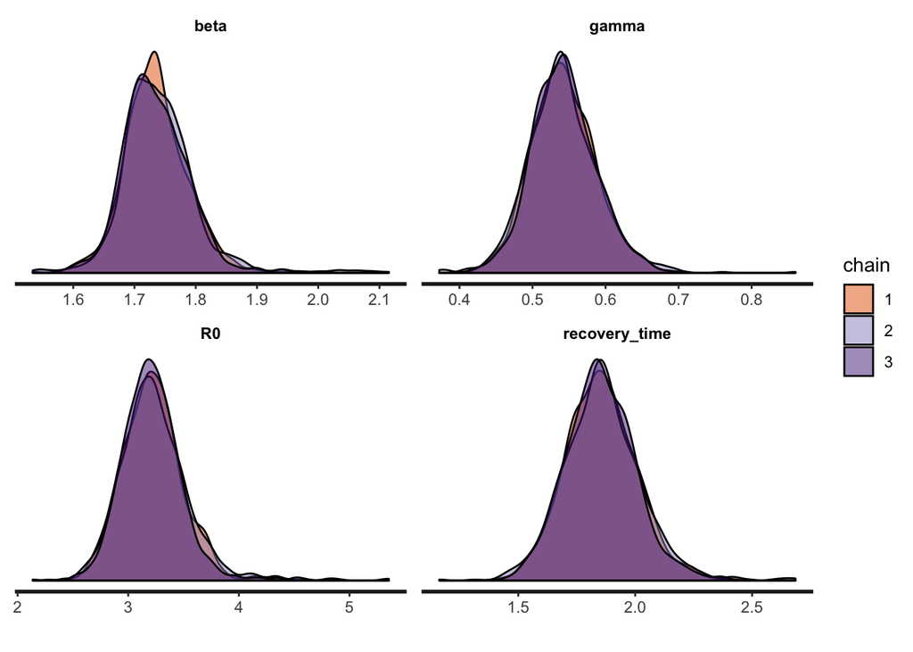

```r
pars=c('beta', 'gamma', "R0", "recovery_time")
stan_dens(r_stan_sir_negbin, pars = pars, separate_chains = TRUE)
```